# Basquin Equation

## User defined S-N curve and Basquin Expression

- Chetan G.  
01/2021

#### Symbols

- $S_u$ = Ultimate tensile strength
- $S_a$ = Stress Amplitude
- $k$ = Constant exponent
- $N$ = Fatigue life
- $\sigma'_f$ = Fatigue Strength Coefficient
- $b$ = Fatigue Strength Exponent
- $\Delta \sigma_1$ = maximum principal stress
- $\frac{\Delta \sigma_1} {2}$ = maximum principal stress amplitude
- $N_f$ = Number of cycles
- $2N_f$ = Number of reversal to failure
- $\sigma_m$ = mean stress along the principal axis

When using NX Simcenter Durability Specialist module [fatigue material properties](https://docs.plm.automation.siemens.com/tdoc/nx/1899/nx_help#uid:xid1128419:index_advanced:xid385327:id973964) should be assigned. For ["Stress Life" approach](https://docs.plm.automation.siemens.com/tdoc/nx/1899/nx_help#uid:xid1128419:index_advanced:xid1593960:xid1604043:xid1604038:xid1604027), the user should either:

- define the S-N curve as a table *or*
- Fatigue Strength Coefficient ($ \sigma'_f $) and Fatigue Strength Exponent ($ b $) values should be entered as stress life expression.

The purpose of this document is to illustrate the fatigue strength expressions.

[figure not shown]

Fig: In this figure fatigue strength properties of Aluminum_5086 is expressed as an expression of Fatigue Strength Coefficient and Fatigue Strength Exponent.

Often for a large range of fatigue life (N) the relation between $log S_a$ and $log N$ is approximately linear. This gives us the following relation:

$ S_a^k * N = constant $ ..[textbook formulation, Schijve, 2001]

$ \frac{\Delta \sigma_1}{2} = \sigma'_f (2N_f)^b$ ..[Siemens formulation, withouth mean stress effect]

$ \frac{\Delta \sigma_1}{2} = (1-\frac{\sigma_m}{S_u}) \sigma'_f (2N_f)^b$ ..[Siemens formulation, Goodman method for mean stress effect]

Now, let us plot the S-N curve based on the fatigue strength expression given in the figure above.

$\sigma'_f = 491$ [MPa]

$b = -0.081$

```python
%matplotlib inline
```

```python
import numpy as np
import matplotlib.pyplot as plt

def basquin_plot(sigma_coeff, b_expo):
    x_axis = np.geomspace(1, 10000000, num=8)
    y_axis = sigma_coeff* np.power(x_axis, b_expo)
    plt.xlabel('Cycles (N)')
    plt.ylabel('Stress amlpitude (S_a)')
    plt.yscale('log')
    plt.xscale('log')
    plt.plot(x_axis, y_axis)
    plt.grid(which='both')
```

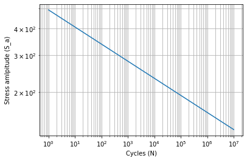

```python
basquin_plot(sigma_coeff=491, b_expo=-0.081)
```

Note that in the above plot, y-axis is stress amplitude, which is $\frac{\Delta \sigma_1}{2}$. If user defined S-N curve values are determined by experiments, make sure to enter the correct values.

Next, let us illustrate the calculation of number of cycles (life) based on the applied stresses. Following codes implements the basquin expression in terms of number of cycles for given stress and in terms of applied stress given the number of cycles. (Without mean stress effect.)

```python
def basquin(sigma_coeff, b_expo, delta_sigma):
    #sigma_coeff and sigma_delta have the same units ex: [MPa]
    cycles = 0.5*np.power(10, (np.log10((delta_sigma/2) / sigma_coeff) / b_expo))
    print('life='+str(cycles))
    return cycles

def basquin_rev(sigma_coeff, b_expo, cycles):
    # sigma_coeff and sigma_delta have the same units ex: [MPa]
    delta_sigma = 2*sigma_coeff* np.power(2*cycles, b_expo)
    print('delta_sigma='+str(delta_sigma))
    return delta_sigma
```

Let us consider the results of a small exercise of dynamic analysis using SOL401 in NX.

[figure not shown]

Fig: Maximum principal stress of element ID 340. The maximum value is 256.15 [MPa] at node 3.

[figure not shown]

Fig: Evaluate the fatigue stress history.

Next, the stress fatigue history is evaluted using the Durability Specialist of NX Simcenter as shown in the figure above. The result of element 340 is shown below:

[figure not shown]

Fig: Maximum stress at element 340 face 3 is 223.79 [MPa].

Note, that the maximum principal stress evaluated by the Nastran solver SOL401 is used in the evaluation of fatigue stress history by the Durability specialist. Durability solver uses its own stress axis method. (Question: how does this method work?)

Finally, the durability is solved. The life for element ID 340 is shown in the figure below:

[figure not shown]

Fig: Life of element ID 340. The minimum value is 4.2486e+07 at node 3.

We can now cross check the results, by solving the basquin expressions.

```python
life = basquin(delta_sigma=223.79, sigma_coeff=491, b_expo=-0.081)
```

```
life=42485357.99692601
```

```python
sigma_delta=basquin_rev(cycles=4.2486e+07, sigma_coeff=491, b_expo=-0.081)
```

```
delta_sigma=223.78972608237754
```

Note that due to logarithmic nature of the S-N curve, small increase in stress can result is large decrease in the expected life. For, example if we had used maximum principal stress of 256.15[Mpa] as the input for fatigue evaluation, then resulting life would be five times low.

```python
life = basquin(delta_sigma=256.15, sigma_coeff=491, b_expo=-0.081)
```

```
life=8018991.026345691
```

### References:

1. Schijve, J. (2001). *Fatigue of structures and materials.* Springer Science & Business Media.
2. Stress Life - Siemens documentation  
   https://docs.plm.automation.siemens.com/tdoc/nx/1899/nx_help#uid:xid1128419:index_advanced:xid385327:id635096:id624881:id975729
3. Siemens documentation pages  
   https://docs.plm.automation.siemens.com/tdoc/nx/1899/nx_help#uid:xid1128419:index_advanced:xid1593960  
   https://docs.plm.automation.siemens.com/tdoc/nx/1899/nx_help#uid:xid1128419:index_advanced:xid385327  
   https://docs.plm.automation.siemens.com/tdoc/nx/1899/nx_help#uid:xid1128419:index_advanced:xid385327:id973964  
   https://docs.plm.automation.siemens.com/tdoc/nx/1899/nx_help#uid:xid1128419:index_advanced:xid1593960:xid1604043:xid1604038:xid1604027  
   https://docs.plm.automation.siemens.com/tdoc/nx/1899/nx_help#uid:xid1128419:index_advanced:xid385327:id635096:id624881:xid456177